# Minimal intro to sienaBayes

Johan Koskinen and T.A.B. Snijders

2024-06-19

# Preamble

## Package

```r
require(RSiena)
require(multiSiena)
```

## Load mock dataset

Use a routine for creating synthetic dataset with 6 networks

```r
source("https://raw.githubusercontent.com/johankoskinen/Sunbelt2024/main/multiSiena/data.set.enzo.setup.R")
```

This dataset, `enzo`,

```r
enzo <- create.enzo()
```

is a `sienaGroup` object.

## What data

Plot the 6 networks for the two waves. For each group $j=1,\ldots,6$, we have adjacency matrices
$$\boldsymbol{x}^{(j)}(t_0), \text{ and } \boldsymbol{x}^{(j)}(t_1)$$
For example, for group $j=1$, $\boldsymbol{x}^{(j)}(t_0)$

```r
enzo$Data1$depvars[[1]][,,1]
```

```
##      [,1] [,2] [,3] [,4] [,5]
## [1,]    0    1    0    0    0
## [2,]    1    0    0    0    0
## [3,]    0    0    0    1    0
## [4,]    0    0    0    0    1
## [5,]    0    0    0    0    0
```

and $\boldsymbol{x}^{(j)}(t_1)$

```r
enzo$Data1$depvars[[1]][,,2]
```

```
##      [,1] [,2] [,3] [,4] [,5]
## [1,]    0    1    0    0    0
## [2,]    1    0    0    0    0
## [3,]    0    0    0    0    1
## [4,]    0    0    1    0    1
## [5,]    0    0    0    1    0
```

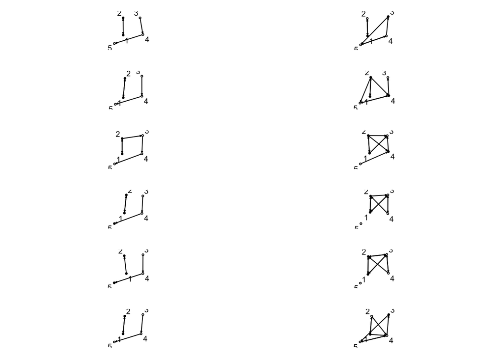

```r
require(sna)
coord <- matrix(c(1,1,
1,2,
2,2,
2,1,
.5,.5),5,2,byrow=TRUE)
# === plot
par( mfrow = c(6,2) ,oma = c(0,1,0,0) + 0.1,
          mar = c(1,0,1,1) + 0.1)
# grp1
gplot( enzo$Data1$depvars[[1]][,,1] ,coord = coord, vertex.col = enzo$Data1$depvars[[2]][,1,1], label=c(1:5))
gplot( enzo$Data1$depvars[[1]][,,2] , coord = coord, vertex.col = enzo$Data1$depvars[[2]][,1,2], label=c(1:5))
# grp2
gplot( enzo$Data2$depvars[[1]][,,1] ,coord = coord, vertex.col = enzo$Data2$depvars[[2]][,1,1], label=c(1:5))
gplot( enzo$Data2$depvars[[1]][,,2] , coord = coord, vertex.col = enzo$Data2$depvars[[2]][,1,2], label=c(1:5))
# grp3
gplot( enzo$Data3$depvars[[1]][,,1] ,coord = coord, vertex.col = enzo$Data3$depvars[[2]][,1,1], label=c(1:5))
gplot( enzo$Data3$depvars[[1]][,,2] , coord = coord, vertex.col = enzo$Data3$depvars[[2]][,1,2], label=c(1:5))
# grp4
gplot( enzo$Data4$depvars[[1]][,,1] ,coord = coord, vertex.col = enzo$Data4$depvars[[2]][,1,1], label=c(1:5))
gplot( enzo$Data4$depvars[[1]][,,2] , coord = coord, vertex.col = enzo$Data4$depvars[[2]][,1,2], label=c(1:5))
# grp5
gplot( enzo$Data5$depvars[[1]][,,1] ,coord = coord, vertex.col = enzo$Data5$depvars[[2]][,1,1], label=c(1:5))
gplot( enzo$Data5$depvars[[1]][,,2] , coord = coord, vertex.col = enzo$Data5$depvars[[2]][,1,2], label=c(1:5))
# grp6
gplot( enzo$Data6$depvars[[1]][,,1] ,coord = coord, vertex.col = enzo$Data6$depvars[[2]][,1,1], label=c(1:5))
gplot( enzo$Data6$depvars[[1]][,,2] , coord = coord, vertex.col = enzo$Data6$depvars[[2]][,1,2], label=c(1:5))
```

# Basic Model

For eaxh group $j=1,\ldots,6$ we define a **stochastic actor-oriented model**
$$\boldsymbol{x}^{(j)}(t_1) \mid \boldsymbol{x}^{(j)}(t_0) \thicksim
SAOM(\theta_j)$$
The $SAOM(\theta)$ is determined by its **objective** and **rate** functions
$$f_i(\boldsymbol{x},\theta)\text{, and } \lambda_i(\theta)$$
that are assumed to be the same for all groups $j=1,\ldots,N$.

## Define model

You define the *effects* of the objective function of the model in the standard way. The effects structure is obtained from `getEffects()`

```r
seed <- 1234
GroupEffects <- getEffects(enzo)
GroupsModel <- sienaAlgorithmCreate(projname = 'Enzo',seed=seed)
```

```
## If you use this algorithm object, siena07 will create/use an output file Enzo.txt .
```

## Hierarchial model

All groups have the same effects and model, $SAOM(\theta_j)$, but some of the parameters, $\gamma_j$, vary across groups, and some, $\eta$, are the same for all groups.

$$\theta_j=\begin{bmatrix}\gamma_j\\\eta\end{bmatrix}$$

### Group-varying and fixed

By default

```r
summary(GroupEffects)$random
```

```
##  [1] FALSE FALSE FALSE FALSE FALSE FALSE  TRUE FALSE FALSE FALSE FALSE FALSE
## [13] FALSE FALSE FALSE
```

```r
summary(GroupEffects)$effectName[summary(GroupEffects)$random]
```

```
## [1] "outdegree (density)"
```

```r
summary(GroupEffects)$effectName[summary(GroupEffects)$random==FALSE]
```

```
##  [1] "constant net rate (period 1)"  "constant net rate (period 3)"
##  [3] "constant net rate (period 5)"  "constant net rate (period 7)"
##  [5] "constant net rate (period 9)"  "constant net rate (period 11)"
##  [7] "reciprocity"                   "rate beh (period 1)"
##  [9] "rate beh (period 3)"           "rate beh (period 5)"
## [11] "rate beh (period 7)"           "rate beh (period 9)"
## [13] "rate beh (period 11)"          "beh linear shape"
```

### Model for group-varying

The model assumes that the group-varying parameters follow a **multivariate normal distribution**
$$\gamma_j \thicksim N(\mu,\Sigma)$$

## Target of inference

We want to estimate the population mean $\mu$ and the non-varying parameter $\eta$.

### Running default

To estimate the model with default settings

```r
groupModel.e <- sienaBayes(GroupsModel, data = enzo,
                initgainGlobal=0.1, initgainGroupwise = 0.001,
                effects = GroupEffects,
             nrunMHBatches=40, silentstart=FALSE)
```

## Results

What did we get?

Check objects returned

```r
names(groupModel.e)
```

### Non-varying

```r
dim(groupModel.e$ThinPosteriorEta)
```

```
## [1] 300   2
```

This corresponds to `reciprocity` and the `linear shape` for behaviour

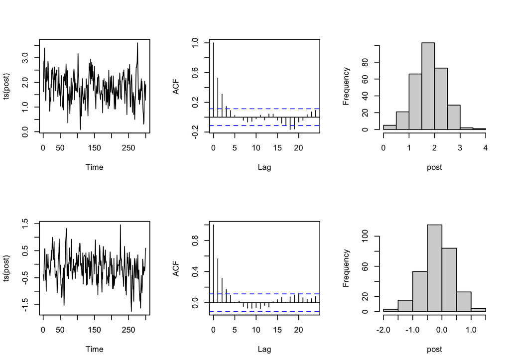

```r
par(mfrow=c(2,3))
for (k in c(1:2)){
  post <- groupModel.e$ThinPosteriorEta[,k]
plot(ts(post))# draws in each iteration
acf(post,main='')# the autocorrelation function - how much dependence
hist(post,main='')# (empirical) posterior distribution
}
```

Note that these are draws from a bivariate distribution

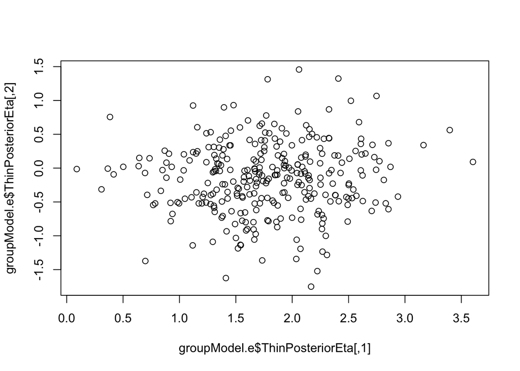

```r
plot(groupModel.e$ThinPosteriorEta)
```

> We can calculate probabilites for the parameters using the values simulated from the posterior

For example, we can calculate the probability that the reciprocity parameter is positive **given data** as

```r
mean(groupModel.e$ThinPosteriorEta[,1]>0)
```

```
## [1] 1
```

> Given these 6 (synthetic) networks, the reciprocity parameter is positive with a posterior probability of 1

### Population parameters

The posteriors for $\mu$ are found in `ThinPosteriorMu`

```r
dim(groupModel.e$ThinPosteriorMu)
```

```
## [1] 300   3
```

Corresponding to the rate for the network, density, and rate for behaviour

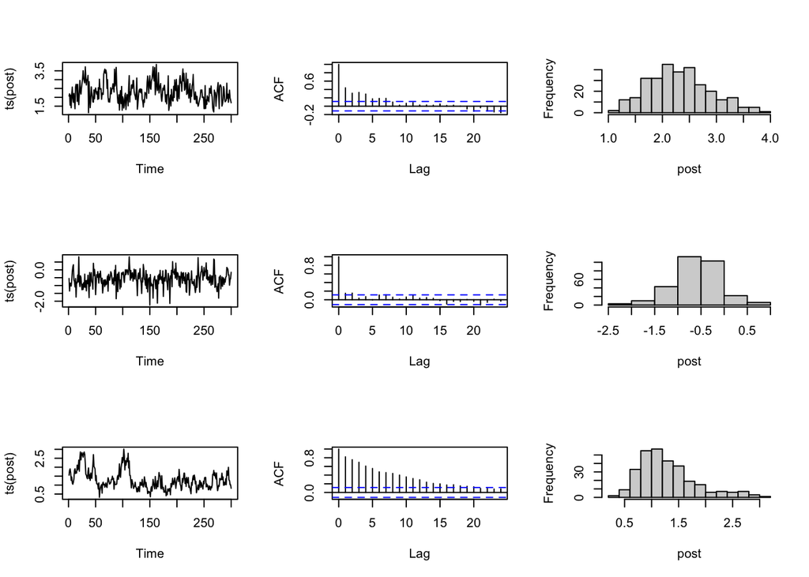

```r
par(mfrow=c(3,3))
for (k in c(1:3)){
  post <- groupModel.e$ThinPosteriorMu[,k]
plot(ts(post))
acf(post,main='')
hist(post,main='')
}
```

## Summary of results

To get a table to numerical summaries of the posteriors

```r
summary(groupModel.e)
```

```
## Bayesian estimation.
## Prior distribution:
##
## Mu      basic rate parameter net    2.5161
##         outdegree (density)         0.0000
##         rate beh period 1           0.7323
##
## Sigma     0.5812   0.0000  -0.1585
##           0.0000   1.0000   0.0000
##          -0.1585   0.0000   0.1310
##
## Prior Df  5
##
## Kappa     0.0000
##
## Eta
## For the fixed parameters, constant prior.
##
## Algorithm specifications were  nprewarm = 50 , nwarm = 50 , nmain = 250 , nrunMHBatches = 40 , nImproveMH = 100 ,
##  nSampVarying = 1 , nSampConst = 1 , mult = 5 .
## Posterior means and standard deviations are averages over the last 250 runs.
##
## Proportion of acceptances in MCMC proposals after warming up:
## 0.19 0.20 0.23 0.24 0.26 0.31 0.25 0.25
##
## This should ideally be between 0.15 and 0.50.
## Note: this summary does not contain a convergence check.
## Note: the print function for sienaBayesFit objects can also use a parameter nfirst,
##       indicating the first run from which convergence is assumed.
##
## Groups:
##  Data1   Data2   Data3   Data4   Data5   Data6
##
## Posterior means and standard deviations for global mean parameters
##
## Total number of runs in the results is  300 .
## Posterior means and standard deviations are averages over 250 MCMC runs (excluding warming, after thinning).
##
##                                          Post.      Post.     cred.    cred.   p      varying   Post.    cred.   cred.
##                                          mean       s.d.m.    from     to                       s.d.     from    to
```

[output cut: 18 more lines]

```
##
## Posterior mean of global covariance matrix (varying parameters)
##   0.6371  -0.0077  -0.1424
##  -0.0077   0.9590   0.0054
##  -0.1424   0.0054   0.1591
##
## Posterior standard deviations of elements of global covariance matrix
##   0.3928   0.3808   0.1483
##   0.3808   0.8117   0.1823
##   0.1483   0.1823   0.0921
##
## For the rate parameters across all groups:
##                          Post.mean Post.sd
## basic rate parameter net   2.30241 0.55871
## rate beh period 1          1.16753 0.44662
```

# Changing hierarchial model

In the previous model, `reciprocity` was assumed to have the same parameter $\theta_{j,rec}=\eta_{rec}$, for all $j=1,\ldots,6$. To allow the `reciprocity` parameter to *vary* across groups $j$, set

```r
GroupEffects <- setEffect( GroupEffects, recip,random=TRUE)
```

```
##   effectName  shortName include fix   test  initialValue parm randomEffects
## 1 reciprocity recip     TRUE    FALSE FALSE          0   0    TRUE
```

so that now
$$\theta_j=\begin{bmatrix}
\gamma_{j,rate_x}\\
\gamma_{j,dens}\\
\gamma_{j,rec}\\
\gamma_{j,rate_z}\\
\eta_{shape,z}
\end{bmatrix}
\text{, and }
\gamma_{j} \thicksim \mathcal{N}_{4}(\mu,\Sigma)$$

### Running new model

To estimate the model with one more random effect

```r
groupModel.e2 <- sienaBayes(GroupsModel, data = enzo,
                initgainGlobal=0.1, initgainGroupwise = 0.001,
                effects = GroupEffects,
             nrunMHBatches=40, silentstart=FALSE)
```

### Output

Now we only have one common parameter, one $\eta$

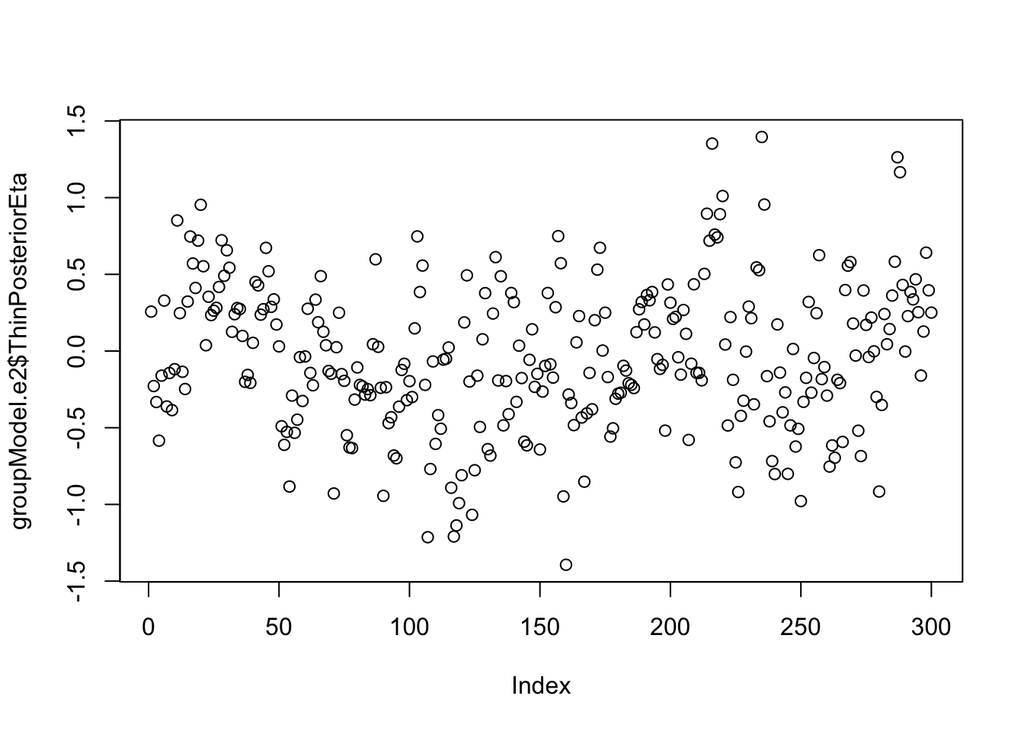

```r
plot(groupModel.e2$ThinPosteriorEta)
```

In the plot we see the 300 simulated values of $\eta$ that are drawn using MCMC from the posterior distribution of $\eta$ given data.

But we have $\mu$ has four dimentions (parameters)

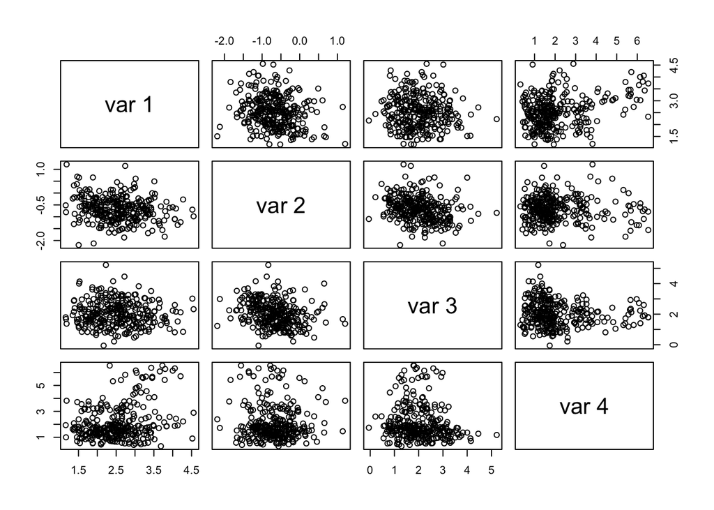

```r
pairs(groupModel.e2$ThinPosteriorMu)
```

We can calculate the probability that the reciprocity parameter is positive **given data** as

```r
mean(groupModel.e2$ThinPosteriorMu[,3]>0)
```

```
## [1] 0.9966667
```

# Group-level analysis

For reciprocity, we saw in the previous example that
$$\Pr(\mu_{rec}>0 \mid Data) \approx 1$$
but what about the group-level parameters $\gamma_{1,rec},\gamma_{2,rec},\ldots,\gamma_{6,rec}$ - are they always positive for all of the groups?

## Group and population-level

The posterior (predictive) distributions of the $\gamma_{j}$’s are stored in `ThinParameters` as **iteration** by **group** by **parameter**

```r
dim(groupModel.e2$ThinParameters)
```

```
## [1] 300   6   5
```

and within each group

```r
head(groupModel.e2$ThinParameters[,1,])
```

```
##      constant net rate outdegree (density) reciprocity rate beh
## [1,]          3.084515          -1.8143328  2.38747125 1.188040
## [2,]          2.534277          -0.8095603  2.10497307 1.392641
## [3,]          3.319430          -0.5882144  0.66770252 1.857220
## [4,]          2.482389          -1.6900750  1.84137145 2.622582
## [5,]          3.122526          -1.6681452  1.25374655 1.728405
## [6,]          3.727048          -0.9129924  0.06870421 1.269398
##      beh linear shape
## [1,]        0.2569260
## [2,]       -0.2283378
## [3,]       -0.3325189
## [4,]       -0.5843580
## [5,]       -0.1605018
## [6,]        0.3287635
```

To illustrate how we have inference for $\mu$ for density and reciprocity, but also for $\gamma_j$ for density and reciprocity for each group, let us plot density against reciprocity for both levels

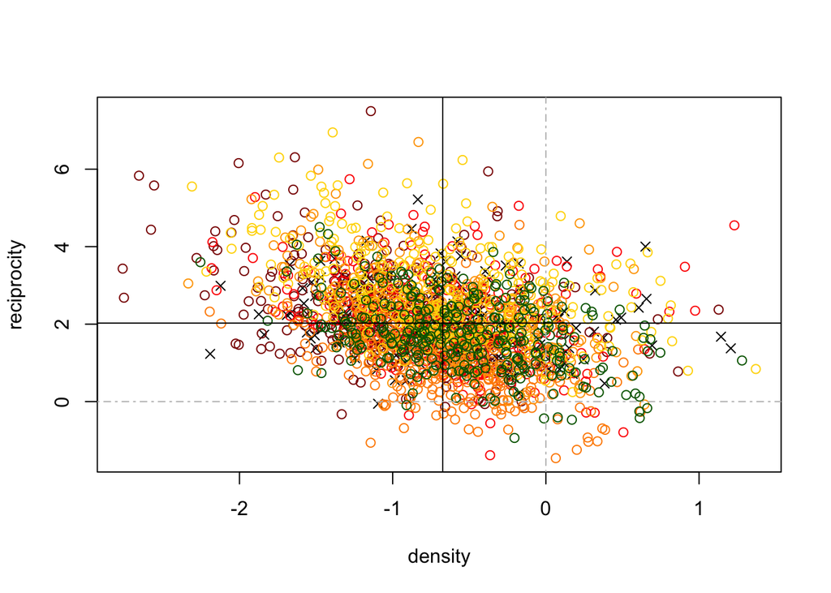

```r
plot(groupModel.e2$ThinPosteriorMu[,2],
     groupModel.e2$ThinPosteriorMu[,3],
     xlim=range(groupModel.e2$ThinParameters[,,2]),
     ylim=range(groupModel.e2$ThinParameters[,,3]),
     pch=4, xlab='density',ylab='reciprocity')
grp.cols <- c('darkred','red','darkorange','orange','gold','darkgreen')
for (j in c(1:6))
{
  lines( groupModel.e2$ThinParameters[,j,2], groupModel.e2$ThinParameters[,j,3],type='p',pch=1,col=grp.cols[j])
}
abline(v=mean(groupModel.e2$ThinPosteriorMu[,2]))
abline(h=mean(groupModel.e2$ThinPosteriorMu[,3]))
abline(v=0,col='grey',lty=4)
abline(h=0,col='grey',lty=4)
```

For an individual parameter it is common to look at the catepilar plot

```r
require(HDInterval)
```

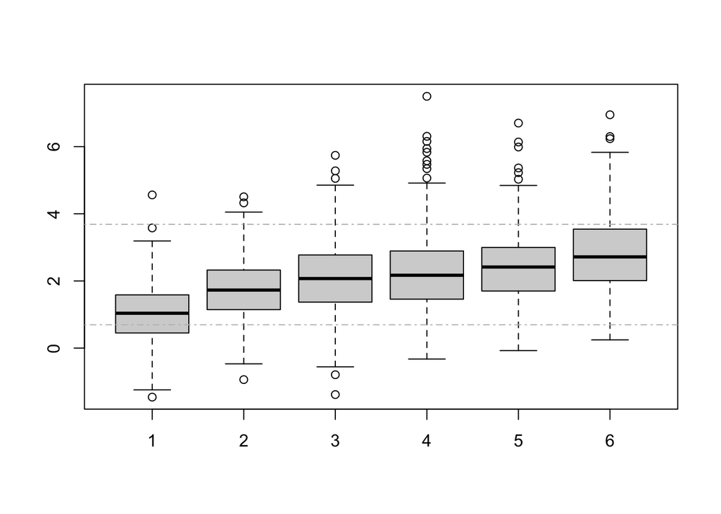

```r
grp.means <- colMeans(groupModel.e2$ThinParameters[,,3])
boxplot(groupModel.e2$ThinParameters[,order(grp.means),3])
CI <- hdi(groupModel.e2$ThinPosteriorMu[,3],1-.05)
abline(h=CI[1],col='grey',lty=4)
abline(h=CI[2],col='grey',lty=4)
```

# Prior and posterior

To get a posterior distribution for $\mu$ and $\eta$ (and $\Sigma$), we need to have **prior distributions** for these parameters

> A prior distribution for a parameter quantifies the uncertainty that we have about a parameter before we collect and observe DATA

## Example: Bernoulli graph

For a cross-section $n=5$ network, a Bernoulli graph says that each of the $5(5-1)/2=10$ possible ties all have a probability of $p$ of being present, independently of each other. The parameter $0 \leq p \leq 1$ and hence a prior for $p$ might be $p \thicksim Beta(\alpha,\beta)$

```r
alpha.p <- 2
beta.p <- 2
```

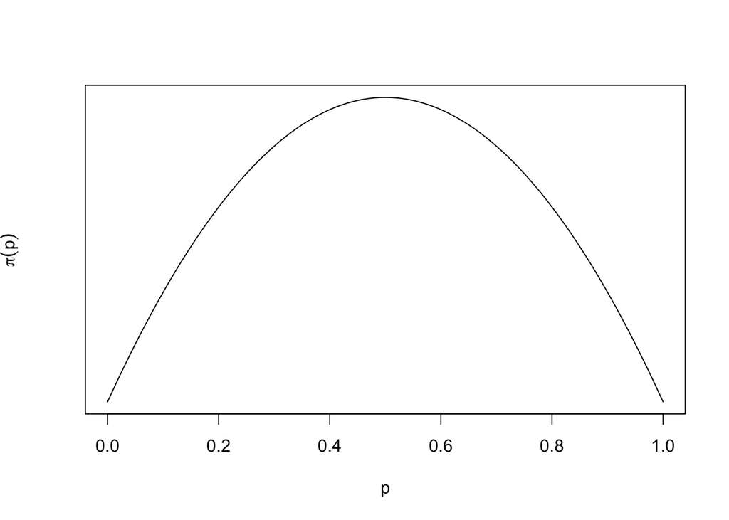

```r
p <- seq(from=.0001,to =.9999, length.out = 1000)
plot( p , dbeta(p, alpha.p, beta.p) , type = 'l', yaxt='n',ylab=expression(pi(p)))
```

Assume that we observe the network

$$\mathbf{X}=
\begin{bmatrix}
- & 1 & 0 & 0 & 0 \\
- & - & 0 & 1 & 0 \\
- & - & - & 0 & 0 \\
- & - & - & - & 0 \\
- & - & - & - & - \\
\end{bmatrix}$$

This has $L=\sum_{i<j}x_{ij}=2$, which gives the **likelihood** function for $p$

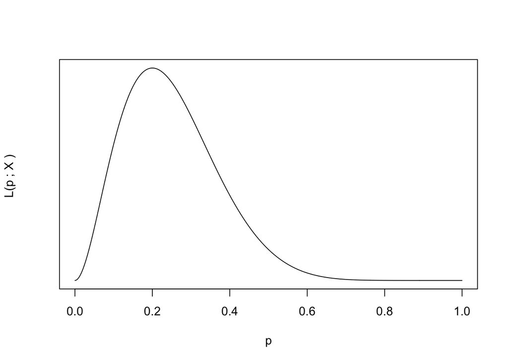

```r
plot(p,p^2*(1-p)^8, type = 'l', yaxt='n',ylab='L(p ; X ) ' )
```

The posterior distribution will be $p \mid \mathbf{X} \thicksim Beta(2+\alpha,8+\beta)$

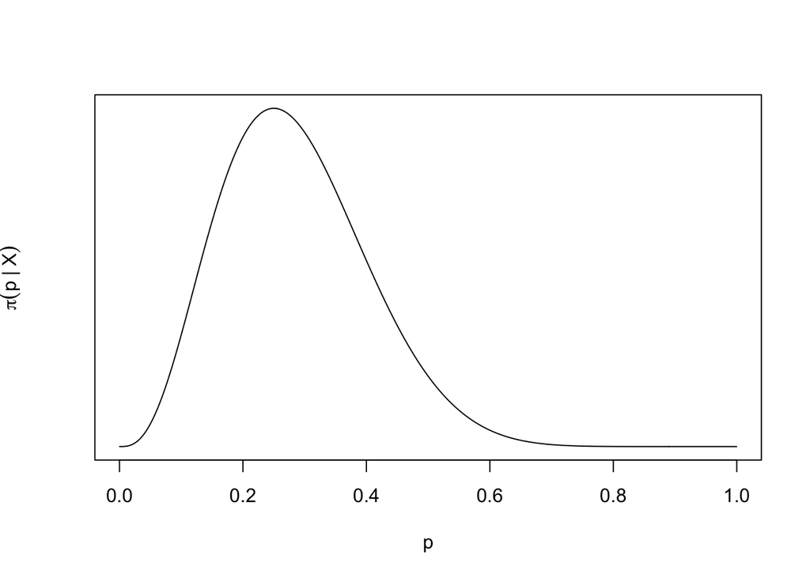

```r
plot( p , dbeta(p, alpha.p+2, beta.p+8) , type = 'l', yaxt='n',ylab=expression(pi(p ~"|"~ X)))
```

> Try with different values of the hyperparameters $\alpha$ and $\beta$ in the prior for $p$

Even better, try Mattias Villani’s widget that illustates Bayesian inference https://observablehq.com/@mattiasvillani/bayesian-inference-for-bernoulli-iid-data?collection=@mattiasvillani/bayesian-learning[Beta-Binomial]

# More and bigger

Load routies

Create two waves for $M$ networks, all of size $n$

```r
n <- 10 # you could make this larger or smaller
M <- 5 # this is very few groups and you could try to produce many
```

The `Karen` dataset has as many groups as you like

```r
Karen <- data.set.karen.set.up(n=10,# number of nodes
                      M=5,# number of networks
                      seed=123,nbrNodes=1,nmain=20,nwarm=20)
```

The networks are simulated from a model with effects, that in addition to the defaults have

- `transTrip`
- `simX` with `interaction1 = "beh"`

Now, figure out what inputs you need. The `sienaGroup` object is `Karen$my.Karen`

```r
Karen$my.Karen
```

```
## Dependent variables:
## net : oneMode
##  beh : behavior
## Total number of groups: 5
## Total number of periods: 5
```

> For different model specifications, think of what priors you need to specify. Which ones should be random and which fixed?

> With the same prior, how does increasing $M$ affect inference?

> Increasing the prior variance ($\Sigma$), how does that affect inference?

```r
groupModel.e <- sienaBayes(Karen$GroupsModel, data = Karen$my.Karen,
                            initgainGlobal=0.1, initgainGroupwise = 0.001,
                            effects = Karen$effects, priorMu = Karen$priorMu, priorSigma = Karen$priorSigma,
                            priorKappa = 0.01,
                            nwarm=Karen$nwarm, nmain=Karen$nmain, nrunMHBatches=40,
                            nbrNodes=Karen$nbrNodes, silentstart=FALSE)
```